# Bidirectional voltage source converter

A three-phase sinusoidal pulse width modulated voltage source converter is connected to a three-phase balanced $400\,$V, $50\,$Hz AC voltage source through inductors ($10\,$mH each) as shown in the figure. The converter is supplying a balanced three-phase current to the source. The DC side of the converter is maintained at $800\,$V. The three-phase balanced modulation voltages are $m_a(t)$, $m_b(t)$, $m_c(t)$, and the triangular carrier voltage is $v_c(t)$. The A-phase modulating voltage is $m_a(t) = 0.5\,\sin\,(100\,\pi\,t + 30^{\circ})$. The fundamental frequency of the source is $f$. Which frequency components are present in the DC link current $i_{dc}$?

1. $f$, $2\,f$, and switching frequency components
2. only switching frequency components
3. $2\,f$ and switching frequency components
4. $3\,f$ and switching frequency components

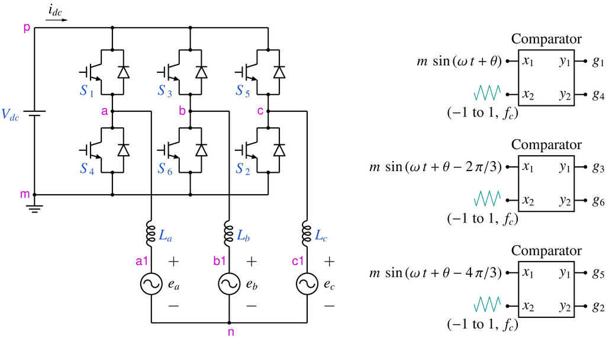

```python
from IPython.display import Image
Image(filename =r'VSC_bi_8_fig_1.png', width=750)
```

```python
# run this cell to view the circuit file.
%pycat VSC_bi_8_orig.in
```

We now replace the strings such as `\$Vdc`, `\$L`, with the values of our choice by running the python script given below. It takes an existing circuit file `VSC_bi_8_orig.in` and produces a new circuit file `VSC_bi_8.in`, after replacing `\$Vdc`, `\$L`, etc. with values of our choice.

```python
import gseim_calc as calc
import numpy as np
s_Vdc = "800"

VL = 400.0
A_sin = VL*np.sqrt(2/3)
s_ea = ("%11.4E"%(A_sin)).strip()

s_L = "0.01"
s_R = "0.001"
s_sin = "0.5"
s_f_sin = "50"
s_f_carrier = "10e3"
s_dt_min = "0.01e-6"
s_dt_nrml = "1e-6"

phi_a_sin = 30.0
phi_b_sin = phi_a_sin - 120.0
phi_c_sin = phi_a_sin - 240.0

s_phi_a_sin = ("%11.4E"%(phi_a_sin)).strip()
s_phi_b_sin = ("%11.4E"%(phi_b_sin)).strip()
s_phi_c_sin = ("%11.4E"%(phi_c_sin)).strip()

l = [
  ('$Vdc', s_Vdc),
  ('$L', s_L),
  ('$R', s_R),
  ('$A_ea', s_ea),
  ('$A_sin', s_sin),
  ('$f_sin', s_f_sin),
  ('$f_carrier', s_f_carrier),
  ('$dt_min', s_dt_min),
  ('$dt_nrml', s_dt_nrml),
  ('$phi_a_sin', s_phi_a_sin),
  ('$phi_b_sin', s_phi_b_sin),
  ('$phi_c_sin', s_phi_c_sin),
]
calc.replace_strings_1("VSC_bi_8_orig.in", "VSC_bi_8.in", l)
print('VSC_bi_8.in is ready for execution')
```

```
VSC_bi_8.in is ready for execution
```

**Execute the following cell to run GSEIM on VSC_bi_8.in.**

```python
import os
import dos_unix
# uncomment for windows:
#dos_unix.d2u("VSC_bi_8.in")
os.system('run_gseim VSC_bi_8.in')
```

```
Circuit: filename = VSC_bi_8.in
main: calling solve_sss
solve_sss starting: sss_n_st: 3
solve_sss_ex: sss_iter_newton=0, rhs_sss_norm=1.8120e-01, sss_period_1_compute=4.0000e-02
solve_sss_ex: sss_iter_newton=1, rhs_sss_norm=4.0775e-11, sss_period_1_compute=4.0000e-02
solve_sss_ex: sss_iter_newton=2, rhs_sss_norm=1.3153e-13, sss_period_1_compute=4.0000e-02
solve_sss_ex: calling sss_solve_trns_ex for one more trns step
Transient simulation starts...
i=0
i=10000
i=20000
i=30000
i=40000
GSEIM: Program completed.
```

```
0
```

The circuit file (`VSC_bi_8.in`) is created in the same directory as that used for launching Jupyter notebook. The last step (i.e., running `GSEIM` on `VSC_bi_8.in`) creates data files called `VSC_bi_8_1.dat`, etc. in the same directory. We can now use the python code below to compute/plot the various quantities of interest.

```
filename: VSC_bi_8_2.dat
filename: VSC_bi_8_3.dat
```

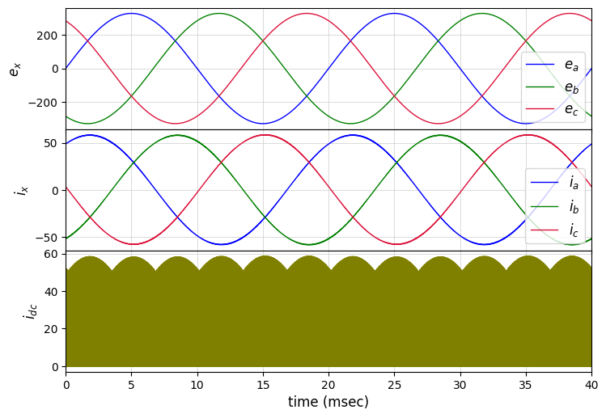

```python
import numpy as np
import matplotlib.pyplot as plt
import gseim_calc as calc
from setsize import set_size

f_hz = 50.0
T = 1.0/f_hz

slv = calc.slv("VSC_bi_8.in")

i_slv = 0
i_out = 1
filename = slv.l_filename_all[i_slv][i_out]
print('filename:', filename)
u1 = np.loadtxt(filename)
t1 = u1[:, 0]

ea = slv.get_array_double(i_slv,i_out,"ea",u1)
eb = slv.get_array_double(i_slv,i_out,"eb",u1)
ec = slv.get_array_double(i_slv,i_out,"ec",u1)

i_out = 2
filename = slv.l_filename_all[i_slv][i_out]
print('filename:', filename)
u2 = np.loadtxt(filename)
t2 = u2[:, 0]

ILa  = slv.get_array_double(i_slv,i_out,"ILa",u2)
ILb  = slv.get_array_double(i_slv,i_out,"ILb",u2)
ILc  = slv.get_array_double(i_slv,i_out,"ILc",u2)
P_ea = slv.get_array_double(i_slv,i_out,"P_ea",u2)
P_eb = slv.get_array_double(i_slv,i_out,"P_eb",u2)
P_ec = slv.get_array_double(i_slv,i_out,"P_ec",u2)
IS   = slv.get_array_double(i_slv,i_out,"IS",u2)

fig, ax = plt.subplots(3, sharex=False, gridspec_kw={'height_ratios': [1, 1, 1]})
plt.subplots_adjust(wspace=0, hspace=0.0)

set_size(6.5, 4.5, ax[0])

for i in range(3):
    ax[i].set_xlim(left=0.0, right=2.0*T*1e3)
    ax[i].grid(color='#CCCCCC', linestyle='solid', linewidth=0.5)

ax[0].set_ylabel(r'$e_x$'   , fontsize=12)
ax[1].set_ylabel(r'$i_x$'   , fontsize=12)
ax[2].set_ylabel(r'$i_{dc}$', fontsize=12)

ax[0].tick_params(labelbottom=False)
ax[1].tick_params(labelbottom=False)

color1 = "blue"
color2 = "green"
color3 = "crimson"
color4 = "olive"

ax[0].plot(t1*1e3, ea, color=color1, linewidth=1.0, label="$e_a$")
ax[0].plot(t1*1e3, eb, color=color2, linewidth=1.0, label="$e_b$")
ax[0].plot(t1*1e3, ec, color=color3, linewidth=1.0, label="$e_c$")

ax[1].plot(t2*1e3, ILa, color=color1, linewidth=1.0, label="$i_a$")
ax[1].plot(t2*1e3, ILb, color=color2, linewidth=1.0, label="$i_b$")
ax[1].plot(t2*1e3, ILc, color=color3, linewidth=1.0, label="$i_c$")

ax[2].plot(t2*1e3, IS , color=color4, linewidth=1.0, label="$i_{dc}$")

ax[2].set_xlabel('time (msec)', fontsize=12)

for k in range(2):
    ax[k].legend(loc = 'lower right',frameon = True, fontsize = 10, title = None,
        markerfirst = True, markerscale = 1.0, labelspacing = 0.5, columnspacing = 2.0,
        prop = {'size' : 12})

#plt.tight_layout()
plt.show()
```

```
filename: VSC_bi_8_3.dat
```

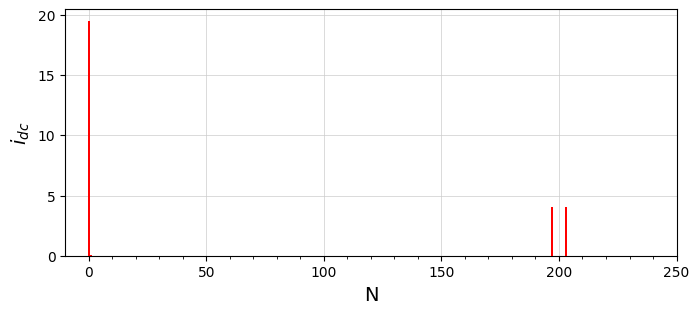

```python
import numpy as np
import matplotlib.pyplot as plt
from matplotlib.ticker import (MultipleLocator, AutoMinorLocator)
import gseim_calc as calc
from setsize import set_size

slv = calc.slv("VSC_bi_8.in")

i_slv = 0
i_out = 2
filename = slv.l_filename_all[i_slv][i_out]
print('filename:', filename)
u = np.loadtxt(filename)
t = u[:, 0]
t0 = t[0]
t = t - t0

IS = slv.get_array_double(i_slv,i_out,"IS",u)

# since we have stored two cycles, we need to divide the last time point
# by 2 to get the period:

T = t[-1]/2

# compute Fourier coeffs:

t_start = T
t_end = 2.0*T

n_fourier = 250

coeff_IS, thd_IS = calc.fourier_coeff_1C(t, IS,
    t_start, t_end, 1.0e-8, n_fourier)

x = np.linspace(0, n_fourier, n_fourier+1)

y_IS = np.array(coeff_IS)

fig, ax = plt.subplots()
plt.subplots_adjust(wspace=0, hspace=0.0)

set_size(5.5, 2.5, ax)

plt.grid(color='#CCCCCC', linestyle='solid', linewidth=0.5)

delta = 50.0
x_major_ticks = np.arange(0.0, (float(n_fourier+1)), delta)
x_minor_ticks = np.arange(0.0, (float(n_fourier+1)), delta/5)

ax.set_xlim(left=-10.0, right=float(n_fourier))
ax.set_xticks(x_major_ticks)
ax.set_xticks(x_minor_ticks, minor=True)
ax.grid(visible=True, which='major', axis='x', color='#CCCCCC', linestyle='-', zorder=0)
ax.set_ylabel('$i_{dc}$',fontsize=14)
ax.set_xlabel('N', fontsize=14)

bars1 = ax.bar(x, y_IS, width=0.7, color='red',  label="$i_{dc}$", zorder=3)

plt.tight_layout()
plt.show()
```

This notebook was contributed by **Prof. Nakul Narayanan K**, Govt. Engineering College, Thrissur. He may be contacted at nakul@gectcr.ac.in.